# Assignment_2_ARM

Swapnil_Sethi

10/1/2022

## R Markdown

```r
library(viridis)
library(arules)
```

```r
library(TSP)
library(data.table)
#library(ggplot2)
#library(Matrix)
#library(tcltk)
library(dplyr)
#library(devtools)
library(purrr)
library(tidyr)
library(arulesViz)
```

Gathering Data

## Performing ARM analysis on product Categories

```r
Categories <- read.transactions("https://raw.githubusercontent.com/swapnilsethi/Machine-Learning-and-Neural-Network/main/ML%20Project/transaction%20data%20for%20ARM/transaction_Categories.csv",
                             rm.duplicates = FALSE,
                             format = "basket",
                             sep=",",
                             cols=NULL)
dim(Categories)
```

```
## [1] 11946 12015
```

```r
Frules = arules::apriori(Categories, parameter = list(support=.0004,
                                          confidence=.1, minlen=2))
```

```
## Apriori
##
## Parameter specification:
##  confidence minval smax arem  aval originalSupport maxtime support minlen
##         0.1    0.1    1 none FALSE            TRUE       5   4e-04      2
##  maxlen target  ext
##      10  rules TRUE
##
## Algorithmic control:
##  filter tree heap memopt load sort verbose
##     0.1 TRUE TRUE  FALSE TRUE    2    TRUE
##
## Absolute minimum support count: 4
##
## set item appearances ...[0 item(s)] done [0.00s].
## set transactions ...[12015 item(s), 11946 transaction(s)] done [0.01s].
## sorting and recoding items ... [64 item(s)] done [0.00s].
## creating transaction tree ... done [0.00s].
## checking subsets of size 1 2 3 done [0.00s].
## writing ... [14 rule(s)] done [0.00s].
## creating S4 object  ... done [0.00s].
```

```r
inspect(Frules)
```

```
##      lhs                                          rhs                    support confidence    coverage      lift count
## [1]  {art}                                     => {furniture_decor} 0.0005022602  0.3750000 0.001339360 2.6320505     6
## [2]  {audio}                                   => {watches_gifts}   0.0006696802  0.2424242 0.002762431 6.0207900     8
## [3]  {food_drink}                              => {sports_leisure}  0.0004185501  0.1190476 0.003515821 1.2766094     5
## [4]  {kitchen_dining_laundry_garden_furniture} => {furniture_decor} 0.0004185501  0.1162791 0.003599531 0.8161397     5
## [5]  {kitchen_dining_laundry_garden_furniture} => {bed_bath_table}  0.0005022602  0.1395349 0.003599531 0.8932925     6
## [6]  {construction_tools_lights}               => {furniture_decor} 0.0015067805  0.2950820 0.005106312 2.0711217    18
## [7]  {furniture_living_room}                   => {furniture_decor} 0.0009208103  0.1279070 0.007199062 0.8977537    11
## [8]  {furniture_living_room}                   => {bed_bath_table}  0.0007533903  0.1046512 0.007199062 0.6699693     9
## [9]  {home_confort}                            => {bed_bath_table}  0.0045203415  0.5400000 0.008371003 3.4570418    54
## [10] {home_construction}                       => {furniture_decor} 0.0016742006  0.1639344 0.010212623 1.1506232    20
## [11] {cool_stuff}                              => {baby}            0.0025950109  0.1111111 0.023355098 4.1740042    31
## [12] {baby}                                    => {bed_bath_table}  0.0030972711  0.1163522 0.026619789 0.7448786    37
## [13] {furniture_decor,
##       housewares}                              => {bed_bath_table}  0.0005859702  0.1166667 0.005022602 0.7468917     7
## [14] {bed_bath_table,
##       housewares}                              => {furniture_decor} 0.0005859702  0.1044776 0.005608572 0.7333076     7
```

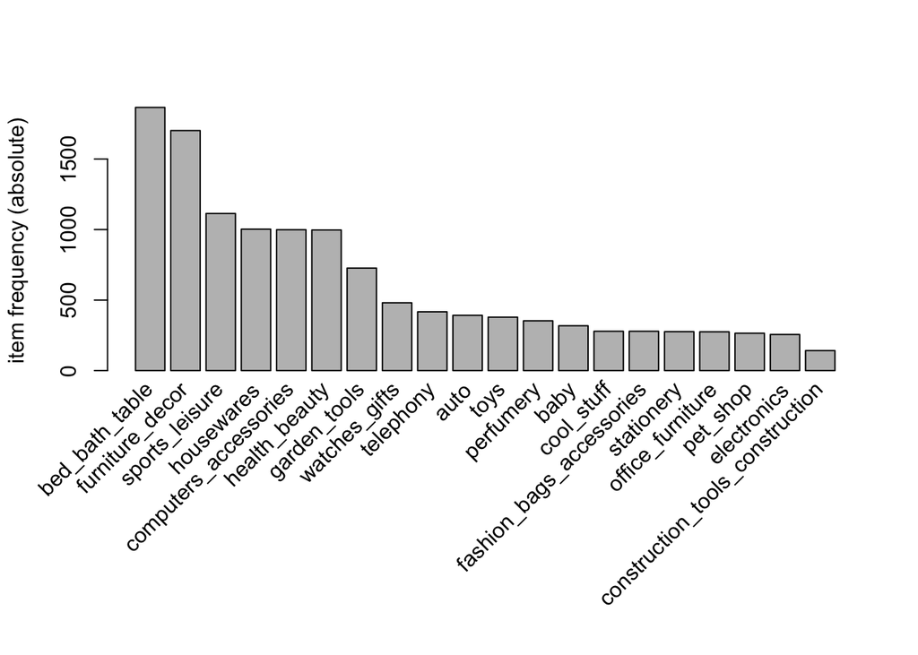

```r
# Most frequent Items
itemFrequencyPlot(Categories, topN=20, type="absolute")
```

## Sort rules by a measure such as conf, sup, or lift

```r
SortedRules <- sort(Frules, by="confidence", decreasing=TRUE)
inspect(SortedRules[1:14])
```

```
##      lhs                                          rhs                    support confidence    coverage      lift count
## [1]  {home_confort}                            => {bed_bath_table}  0.0045203415  0.5400000 0.008371003 3.4570418    54
## [2]  {art}                                     => {furniture_decor} 0.0005022602  0.3750000 0.001339360 2.6320505     6
## [3]  {construction_tools_lights}               => {furniture_decor} 0.0015067805  0.2950820 0.005106312 2.0711217    18
## [4]  {audio}                                   => {watches_gifts}   0.0006696802  0.2424242 0.002762431 6.0207900     8
## [5]  {home_construction}                       => {furniture_decor} 0.0016742006  0.1639344 0.010212623 1.1506232    20
## [6]  {kitchen_dining_laundry_garden_furniture} => {bed_bath_table}  0.0005022602  0.1395349 0.003599531 0.8932925     6
## [7]  {furniture_living_room}                   => {furniture_decor} 0.0009208103  0.1279070 0.007199062 0.8977537    11
## [8]  {food_drink}                              => {sports_leisure}  0.0004185501  0.1190476 0.003515821 1.2766094     5
## [9]  {furniture_decor,
##       housewares}                              => {bed_bath_table}  0.0005859702  0.1166667 0.005022602 0.7468917     7
## [10] {baby}                                    => {bed_bath_table}  0.0030972711  0.1163522 0.026619789 0.7448786    37
## [11] {kitchen_dining_laundry_garden_furniture} => {furniture_decor} 0.0004185501  0.1162791 0.003599531 0.8161397     5
## [12] {cool_stuff}                              => {baby}            0.0025950109  0.1111111 0.023355098 4.1740042    31
## [13] {furniture_living_room}                   => {bed_bath_table}  0.0007533903  0.1046512 0.007199062 0.6699693     9
## [14] {bed_bath_table,
##       housewares}                              => {furniture_decor} 0.0005859702  0.1044776 0.005608572 0.7333076     7
```

```r
(summary(SortedRules))
```

```
## set of 14 rules
##
## rule length distribution (lhs + rhs):sizes
##  2  3
## 12  2
##
##    Min. 1st Qu.  Median    Mean 3rd Qu.    Max.
##   2.000   2.000   2.000   2.143   2.000   3.000
##
## summary of quality measures:
##     support            confidence        coverage             lift
##  Min.   :0.0004186   Min.   :0.1045   Min.   :0.001339   Min.   :0.6700
##  1st Qu.:0.0005232   1st Qu.:0.1163   1st Qu.:0.003600   1st Qu.:0.7642
##  Median :0.0007115   Median :0.1235   Median :0.005357   Median :1.0242
##  Mean   :0.0013394   Mean   :0.1909   Mean   :0.008108   Mean   :1.8775
##  3rd Qu.:0.0016323   3rd Qu.:0.2228   3rd Qu.:0.008078   3rd Qu.:2.4918
##  Max.   :0.0045203   Max.   :0.5400   Max.   :0.026620   Max.   :6.0208
##      count
##  Min.   : 5.00
##  1st Qu.: 6.25
##  Median : 8.50
##  Mean   :16.00
##  3rd Qu.:19.50
##  Max.   :54.00
##
## mining info:
##        data ntransactions support confidence
##  Categories         11946   4e-04        0.1
##                                                                                                 call
##  arules::apriori(data = Categories, parameter = list(support = 4e-04, confidence = 0.1, minlen = 2))
```

home_comfort -> bed_bath_table rule have highest confidence, Which means there are 0.54 times it happend that when someone by product related with home comfort they have also purchased bed_bath_table.

```r
SortedRules <- sort(Frules, by="support", decreasing=TRUE)
inspect(SortedRules[1:14])
```

```
##      lhs                                          rhs                    support confidence    coverage      lift count
## [1]  {home_confort}                            => {bed_bath_table}  0.0045203415  0.5400000 0.008371003 3.4570418    54
## [2]  {baby}                                    => {bed_bath_table}  0.0030972711  0.1163522 0.026619789 0.7448786    37
## [3]  {cool_stuff}                              => {baby}            0.0025950109  0.1111111 0.023355098 4.1740042    31
## [4]  {home_construction}                       => {furniture_decor} 0.0016742006  0.1639344 0.010212623 1.1506232    20
## [5]  {construction_tools_lights}               => {furniture_decor} 0.0015067805  0.2950820 0.005106312 2.0711217    18
## [6]  {furniture_living_room}                   => {furniture_decor} 0.0009208103  0.1279070 0.007199062 0.8977537    11
## [7]  {furniture_living_room}                   => {bed_bath_table}  0.0007533903  0.1046512 0.007199062 0.6699693     9
## [8]  {audio}                                   => {watches_gifts}   0.0006696802  0.2424242 0.002762431 6.0207900     8
## [9]  {furniture_decor,
##       housewares}                              => {bed_bath_table}  0.0005859702  0.1166667 0.005022602 0.7468917     7
## [10] {bed_bath_table,
##       housewares}                              => {furniture_decor} 0.0005859702  0.1044776 0.005608572 0.7333076     7
## [11] {art}                                     => {furniture_decor} 0.0005022602  0.3750000 0.001339360 2.6320505     6
## [12] {kitchen_dining_laundry_garden_furniture} => {bed_bath_table}  0.0005022602  0.1395349 0.003599531 0.8932925     6
## [13] {food_drink}                              => {sports_leisure}  0.0004185501  0.1190476 0.003515821 1.2766094     5
## [14] {kitchen_dining_laundry_garden_furniture} => {furniture_decor} 0.0004185501  0.1162791 0.003599531 0.8161397     5
```

```r
(summary(SortedRules))
```

```
## set of 14 rules
##
## rule length distribution (lhs + rhs):sizes
##  2  3
## 12  2
##
##    Min. 1st Qu.  Median    Mean 3rd Qu.    Max.
##   2.000   2.000   2.000   2.143   2.000   3.000
##
## summary of quality measures:
##     support            confidence        coverage             lift
##  Min.   :0.0004186   Min.   :0.1045   Min.   :0.001339   Min.   :0.6700
##  1st Qu.:0.0005232   1st Qu.:0.1163   1st Qu.:0.003600   1st Qu.:0.7642
##  Median :0.0007115   Median :0.1235   Median :0.005357   Median :1.0242
##  Mean   :0.0013394   Mean   :0.1909   Mean   :0.008108   Mean   :1.8775
##  3rd Qu.:0.0016323   3rd Qu.:0.2228   3rd Qu.:0.008078   3rd Qu.:2.4918
##  Max.   :0.0045203   Max.   :0.5400   Max.   :0.026620   Max.   :6.0208
##      count
##  Min.   : 5.00
##  1st Qu.: 6.25
##  Median : 8.50
##  Mean   :16.00
##  3rd Qu.:19.50
##  Max.   :54.00
##
## mining info:
##        data ntransactions support confidence
##  Categories         11946   4e-04        0.1
##                                                                                                 call
##  arules::apriori(data = Categories, parameter = list(support = 4e-04, confidence = 0.1, minlen = 2))
```

home_comfort -> bed_bath_table rule have highest support, Which means this transaction occured more times than any other transaction in the dataset.

```r
SortedRules <- sort(Frules, by="lift", decreasing=TRUE)
inspect(SortedRules[1:14])
```

```
##      lhs                                          rhs                    support confidence    coverage      lift count
## [1]  {audio}                                   => {watches_gifts}   0.0006696802  0.2424242 0.002762431 6.0207900     8
## [2]  {cool_stuff}                              => {baby}            0.0025950109  0.1111111 0.023355098 4.1740042    31
## [3]  {home_confort}                            => {bed_bath_table}  0.0045203415  0.5400000 0.008371003 3.4570418    54
## [4]  {art}                                     => {furniture_decor} 0.0005022602  0.3750000 0.001339360 2.6320505     6
## [5]  {construction_tools_lights}               => {furniture_decor} 0.0015067805  0.2950820 0.005106312 2.0711217    18
## [6]  {food_drink}                              => {sports_leisure}  0.0004185501  0.1190476 0.003515821 1.2766094     5
## [7]  {home_construction}                       => {furniture_decor} 0.0016742006  0.1639344 0.010212623 1.1506232    20
## [8]  {furniture_living_room}                   => {furniture_decor} 0.0009208103  0.1279070 0.007199062 0.8977537    11
## [9]  {kitchen_dining_laundry_garden_furniture} => {bed_bath_table}  0.0005022602  0.1395349 0.003599531 0.8932925     6
## [10] {kitchen_dining_laundry_garden_furniture} => {furniture_decor} 0.0004185501  0.1162791 0.003599531 0.8161397     5
## [11] {furniture_decor,
##       housewares}                              => {bed_bath_table}  0.0005859702  0.1166667 0.005022602 0.7468917     7
## [12] {baby}                                    => {bed_bath_table}  0.0030972711  0.1163522 0.026619789 0.7448786    37
## [13] {bed_bath_table,
##       housewares}                              => {furniture_decor} 0.0005859702  0.1044776 0.005608572 0.7333076     7
## [14] {furniture_living_room}                   => {bed_bath_table}  0.0007533903  0.1046512 0.007199062 0.6699693     9
```

```r
(summary(SortedRules))
```

```
## set of 14 rules
##
## rule length distribution (lhs + rhs):sizes
##  2  3
## 12  2
##
##    Min. 1st Qu.  Median    Mean 3rd Qu.    Max.
##   2.000   2.000   2.000   2.143   2.000   3.000
##
## summary of quality measures:
##     support            confidence        coverage             lift
##  Min.   :0.0004186   Min.   :0.1045   Min.   :0.001339   Min.   :0.6700
##  1st Qu.:0.0005232   1st Qu.:0.1163   1st Qu.:0.003600   1st Qu.:0.7642
##  Median :0.0007115   Median :0.1235   Median :0.005357   Median :1.0242
##  Mean   :0.0013394   Mean   :0.1909   Mean   :0.008108   Mean   :1.8775
##  3rd Qu.:0.0016323   3rd Qu.:0.2228   3rd Qu.:0.008078   3rd Qu.:2.4918
##  Max.   :0.0045203   Max.   :0.5400   Max.   :0.026620   Max.   :6.0208
##      count
##  Min.   : 5.00
##  1st Qu.: 6.25
##  Median : 8.50
##  Mean   :16.00
##  3rd Qu.:19.50
##  Max.   :54.00
##
## mining info:
##        data ntransactions support confidence
##  Categories         11946   4e-04        0.1
##                                                                                                 call
##  arules::apriori(data = Categories, parameter = list(support = 4e-04, confidence = 0.1, minlen = 2))
```

Though home_comfort -> bed_bath_table have high confidence value and support value, this transaction don’t have highest lift value. Which means there is high chances of buying product from wacthes as well when person purchase product from Audio category.

## Selecting or targeting specific rules RHS

```r
furniture_Rules <- apriori(data=Categories,parameter = list(supp=.001, conf=.01, minlen=2),
                     appearance = list(default="lhs", rhs="furniture_decor"),
                     control=list(verbose=FALSE))
furniture_Rules <- sort(furniture_Rules, decreasing=TRUE, by="confidence")
inspect(furniture_Rules[1:4])
```

```
##     lhs                            rhs               support     confidence
## [1] {construction_tools_lights} => {furniture_decor} 0.001506781 0.29508197
## [2] {home_construction}         => {furniture_decor} 0.001674201 0.16393443
## [3] {bed_bath_table}            => {furniture_decor} 0.013058764 0.08360129
## [4] {garden_tools}              => {furniture_decor} 0.003850661 0.06327373
##     coverage    lift      count
## [1] 0.005106312 2.0711217  18
## [2] 0.010212623 1.1506232  20
## [3] 0.156202913 0.5867808 156
## [4] 0.060857191 0.4441057  46
```

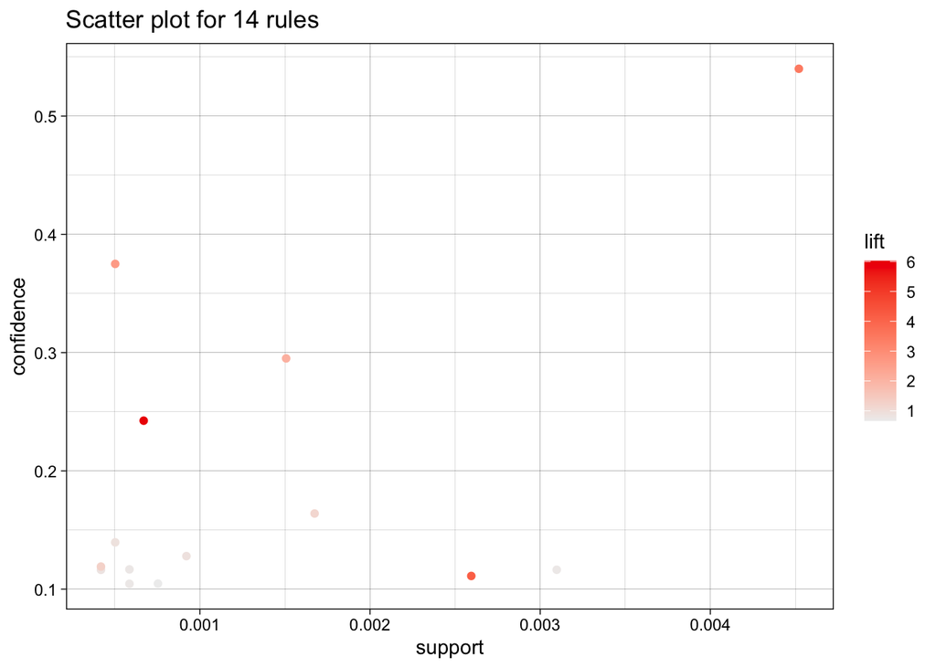

```r
subrules <- head(sort(SortedRules, by="lift"),14)
plot(subrules)
```

```r
plot(subrules, method="graph", engine="htmlwidget")
```

[interactive chart not shown]

## Performing ARM Analysis on Products

```r
products <- read.transactions("https://raw.githubusercontent.com/swapnilsethi/Machine-Learning-and-Neural-Network/main/ML%20Project/transaction%20data%20for%20ARM/products_transaction.csv",
                             rm.duplicates = FALSE,
                             format = "basket",
                             sep=",",
                             cols=NULL)
dim(products)
```

```
## [1] 11673 22099
```

```r
FrulesP = arules::apriori(products, parameter = list(support=.0005,
                                                 confidence=.65, minlen=2))
```

```
## Apriori
##
## Parameter specification:
##  confidence minval smax arem  aval originalSupport maxtime support minlen
##        0.65    0.1    1 none FALSE            TRUE       5   5e-04      2
##  maxlen target  ext
##      10  rules TRUE
##
## Algorithmic control:
##  filter tree heap memopt load sort verbose
##     0.1 TRUE TRUE  FALSE TRUE    2    TRUE
##
## Absolute minimum support count: 5
##
## set item appearances ...[0 item(s)] done [0.00s].
## set transactions ...[22099 item(s), 11673 transaction(s)] done [0.01s].
## sorting and recoding items ... [352 item(s)] done [0.00s].
## creating transaction tree ... done [0.00s].
## checking subsets of size 1 2 3 done [0.00s].
## writing ... [16 rule(s)] done [0.00s].
## creating S4 object  ... done [0.00s].
```

```r
inspect(FrulesP)
```

```
##      lhs                                   rhs                                     support confidence     coverage      lift count
## [1]  {5fc3e6a4b52b0c414458104ed4037f1c} => {5d790355cbeded0cd60e25cbc4c527a2} 0.0005140067  0.8571429 0.0005996745 1250.6786     6
## [2]  {5d790355cbeded0cd60e25cbc4c527a2} => {5fc3e6a4b52b0c414458104ed4037f1c} 0.0005140067  0.7500000 0.0006853422 1250.6786     6
## [3]  {5b8a5a9417210b1b84b67b9a7aefb935} => {e5ae72c62ebfa708624f5029d609b160} 0.0005140067  0.8571429 0.0005996745  909.5844     6
## [4]  {e256d05115f9eb3766f3ab752132a4e2} => {1dc7685f4fdb9622d84ae2ec658d5bbf} 0.0005140067  1.0000000 0.0005140067 1667.5714     6
## [5]  {1dc7685f4fdb9622d84ae2ec658d5bbf} => {e256d05115f9eb3766f3ab752132a4e2} 0.0005140067  0.8571429 0.0005996745 1667.5714     6
## [6]  {e6b314a2236c162ede1a879f1075430f} => {ad4b5def91ac7c575dbdf65b5be311f4} 0.0005996745  0.8750000 0.0006853422 1134.8750     7
## [7]  {ad4b5def91ac7c575dbdf65b5be311f4} => {e6b314a2236c162ede1a879f1075430f} 0.0005996745  0.7777778 0.0007710100 1134.8750     7
## [8]  {060cb19345d90064d1015407193c233d} => {98d61056e0568ba048e5d78038790e77} 0.0005996745  0.7777778 0.0007710100  756.5833     7
## [9]  {4d0ec1e9b95fb62f9a1fbe21808bf3b1} => {9ad75bd7267e5c724cb42c71ac56ca72} 0.0005140067  0.6666667 0.0007710100  518.8000     6
## [10] {a50acd33ba7a8da8e9db65094fa990a4} => {dfb97c88e066dc22165f31648efe1312} 0.0005996745  0.7000000 0.0008566778  742.8273     7
## [11] {18486698933fbb64af6c0a255f7dd64c} => {dbb67791e405873b259e4656bf971246} 0.0008566778  0.9090909 0.0009423456  505.3247    10
## [12] {ee57070aa3b24a06fdd0e02efd2d757d} => {0d85c435fd60b277ffb9e9b0f88f927a} 0.0009423456  0.7857143 0.0011993489  482.7180    11
## [13] {4fcb3d9a5f4871e8362dfedbdb02b064} => {f4f67ccaece962d013a4e1d7dc3a61f7} 0.0016276878  0.8636364 0.0018846912  458.2376    19
## [14] {f4f67ccaece962d013a4e1d7dc3a61f7} => {4fcb3d9a5f4871e8362dfedbdb02b064} 0.0016276878  0.8636364 0.0018846912  458.2376    19
## [15] {3f14d740544f37ece8a9e7bc8349797e} => {36f60d45225e60c7da4558b070ce4b60} 0.0020560267  0.6666667 0.0030840401  102.3947    24
## [16] {e53e557d5a159f5aa2c5e995dfdf244b} => {36f60d45225e60c7da4558b070ce4b60} 0.0041120535  0.6760563 0.0060824124  103.8369    48
```

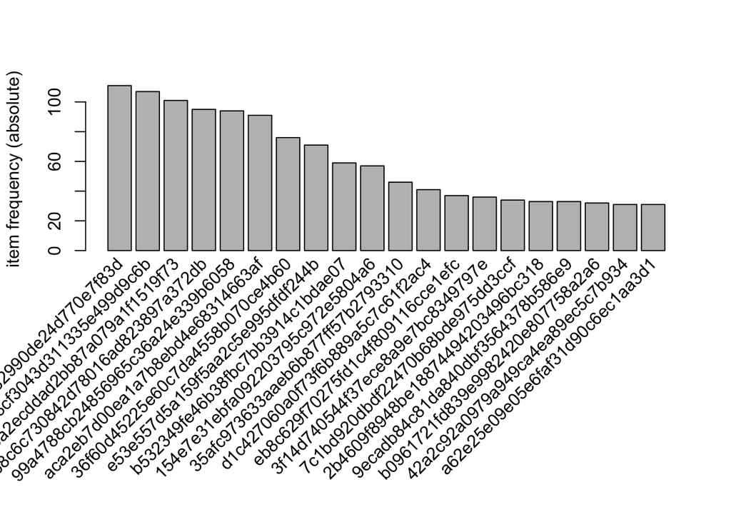

```r
#Most frequents products
itemFrequencyPlot(products, topN=20, type="absolute")
```

```r
SortedRules <- sort(FrulesP, by="confidence", decreasing=TRUE)
inspect(SortedRules[1:14])
```

```
##      lhs                                   rhs                                     support confidence     coverage      lift count
## [1]  {e256d05115f9eb3766f3ab752132a4e2} => {1dc7685f4fdb9622d84ae2ec658d5bbf} 0.0005140067  1.0000000 0.0005140067 1667.5714     6
## [2]  {18486698933fbb64af6c0a255f7dd64c} => {dbb67791e405873b259e4656bf971246} 0.0008566778  0.9090909 0.0009423456  505.3247    10
## [3]  {e6b314a2236c162ede1a879f1075430f} => {ad4b5def91ac7c575dbdf65b5be311f4} 0.0005996745  0.8750000 0.0006853422 1134.8750     7
## [4]  {4fcb3d9a5f4871e8362dfedbdb02b064} => {f4f67ccaece962d013a4e1d7dc3a61f7} 0.0016276878  0.8636364 0.0018846912  458.2376    19
## [5]  {f4f67ccaece962d013a4e1d7dc3a61f7} => {4fcb3d9a5f4871e8362dfedbdb02b064} 0.0016276878  0.8636364 0.0018846912  458.2376    19
## [6]  {5fc3e6a4b52b0c414458104ed4037f1c} => {5d790355cbeded0cd60e25cbc4c527a2} 0.0005140067  0.8571429 0.0005996745 1250.6786     6
## [7]  {5b8a5a9417210b1b84b67b9a7aefb935} => {e5ae72c62ebfa708624f5029d609b160} 0.0005140067  0.8571429 0.0005996745  909.5844     6
## [8]  {1dc7685f4fdb9622d84ae2ec658d5bbf} => {e256d05115f9eb3766f3ab752132a4e2} 0.0005140067  0.8571429 0.0005996745 1667.5714     6
## [9]  {ee57070aa3b24a06fdd0e02efd2d757d} => {0d85c435fd60b277ffb9e9b0f88f927a} 0.0009423456  0.7857143 0.0011993489  482.7180    11
## [10] {ad4b5def91ac7c575dbdf65b5be311f4} => {e6b314a2236c162ede1a879f1075430f} 0.0005996745  0.7777778 0.0007710100 1134.8750     7
## [11] {060cb19345d90064d1015407193c233d} => {98d61056e0568ba048e5d78038790e77} 0.0005996745  0.7777778 0.0007710100  756.5833     7
## [12] {5d790355cbeded0cd60e25cbc4c527a2} => {5fc3e6a4b52b0c414458104ed4037f1c} 0.0005140067  0.7500000 0.0006853422 1250.6786     6
## [13] {a50acd33ba7a8da8e9db65094fa990a4} => {dfb97c88e066dc22165f31648efe1312} 0.0005996745  0.7000000 0.0008566778  742.8273     7
## [14] {e53e557d5a159f5aa2c5e995dfdf244b} => {36f60d45225e60c7da4558b070ce4b60} 0.0041120535  0.6760563 0.0060824124  103.8369    48
```

```r
(summary(SortedRules))
```

```
## set of 16 rules
##
## rule length distribution (lhs + rhs):sizes
##  2
## 16
##
##    Min. 1st Qu.  Median    Mean 3rd Qu.    Max.
##       2       2       2       2       2       2
##
## summary of quality measures:
##     support            confidence        coverage              lift
##  Min.   :0.0005140   Min.   :0.6667   Min.   :0.0005140   Min.   : 102.4
##  1st Qu.:0.0005140   1st Qu.:0.7375   1st Qu.:0.0006639   1st Qu.: 476.6
##  Median :0.0005997   Median :0.8214   Median :0.0007710   Median : 749.7
##  Mean   :0.0010441   Mean   :0.8052   Mean   :0.0013707   Mean   : 821.5
##  3rd Qu.:0.0011137   3rd Qu.:0.8636   3rd Qu.:0.0013707   3rd Qu.:1163.8
##  Max.   :0.0041121   Max.   :1.0000   Max.   :0.0060824   Max.   :1667.6
##      count
##  Min.   : 6.00
##  1st Qu.: 6.00
##  Median : 7.00
##  Mean   :12.19
##  3rd Qu.:13.00
##  Max.   :48.00
##
## mining info:
##      data ntransactions support confidence
##  products         11673   5e-04       0.65
##                                                                                                call
##  arules::apriori(data = products, parameter = list(support = 5e-04, confidence = 0.65, minlen = 2))
```

These generated rules show which products are likely to be bought (consequents) if the customer has already purchased a set of products (antecedents), with more than 50% probability. These rules can be utilized to understand relationship between products and demand within customers. It can also be used to recommend a product to a customer based on what the customer is currently buying.

```
## To reduce overplotting, jitter is added! Use jitter = 0 to prevent jitter.
```

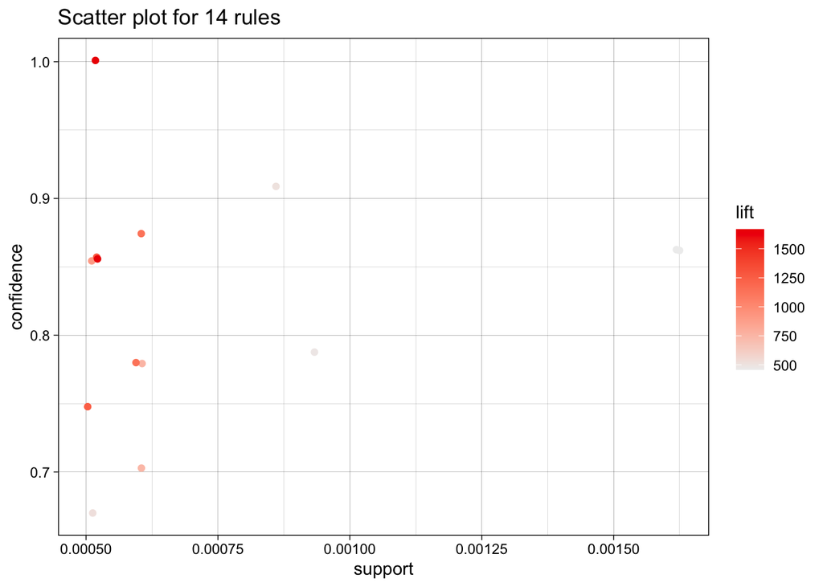

```r
subrules <- head(sort(SortedRules, by="lift"),14)
plot(subrules)
```

```r
plot(subrules, method="graph", engine="htmlwidget")
```

[interactive chart not shown]